# Stat 371 Homework #8 solution. Due Sunday Nov. 1, 11:59 pm

Henry Mendoza Rivera, UW-Madison, Department of Statistics.

# 1 Problem 1: Hypothesis Testing for $\mu_1-\mu_2$ with two independent samples

Several neurosurgeons wanted to determine whether a `dynamic system` (Z-plate) reduced operative time relative to a `static system` (ALPS plate). The operative times, in minutes, for 14 dynamic replications of the operation and 6 static replications were obtained and are given below. The neurosurgeons believe the collection of all operative times with either device would be roughly normally distributed. Test the claim at 0.05 significant level using the steps given in the lecture.

$$\begin{align}
Dynamic:&\; 370, 360, 510, 445, 295, 315, 490, 345, 450, 505, 335, 280, 325, 500\\
Static:&\; 430, 445, 455, 455, 490, 535\\
\end{align}$$

1. State null and alternative hypotheses.
2. Describe the data

   A. Compute a summary statistic (n, mean, sd, min, and max) for both groups. Interpret your findings.

   B. Present a Graph comparison of the variables. Interpret your findings.
3. Check assumptions

   A. Simple random sampling

   B. Independence

   C. Normality

   D. Homogeneity of variance
4. Perform the appropriated Test and make a decision: Use the appropriated R function based on your assumptions. Also, use the bootstrap code provided in the lecture to perform a bootstrap hypothesis test of the hypotheses: use the p-value method and confidence interval method.
5. Write your conclusions

# 2 `Step 1`. State null and alternative hypotheses

1. `Claim`: “To determine whether a `dynamic system` (Z-plate) reduced operative time relative to a `static system` (ALPS plate).”
2. The random variables involved in the claim are:

$$\begin{align}
X_{D}:&\; \textrm{The operative time under a dynamic system (Z-plate).}\\
X_{S}:&\; \textrm{The operative time under the static system (ALPS plate).}\\
X_{D}-X_{S}:&\; \textrm{The mean difference in operative time between a dynamic system and a static system.}
\end{align}$$

`Notice that these variables are quantitative continuous.`

3. The parameter of interest

We will use the notation.

- $\mu_{D} =$ The mean operative time under a dynamic system (Z-plate).
- $\mu_{S} =$ The mean operative time under the static system (ALPS plate).

The parameters are

$$\begin{align}
\textrm{Variable}\; X_{D}:&\; \textrm{The parameter is}\; \mu_{D} \\
\textrm{Variable}\; X_{S}:&\; \textrm{The parameter is}\; \mu_{S} \\
\textrm{Variable}\;X_{D}-X_{S}:&\; \textrm{the parameter is}\; \mu_{S} - \mu_{\textrm{S}}
\end{align}$$

4. The claim in symbolic form is: $\mu_{D} < \mu_{S}$
5. The claim in symbolic form that must be opposite to the original claim is: $\mu_{D} \geq \mu_{S}$ or $\mu_{D} = \mu_{S}$
6. The null hypothesis and alternative hypotheses
   $$\bbox[#ffcc99,20px,border:10px ligth red]
   {
   H_{0}: \mu_{\textrm{D}} = \mu_{S} \;\;\textrm{vs}\;\;H_{A}: \mu_{D} < \mu_{S}
   }$$

Or, equivalently:

$$\bbox[#ffcc99,20px,border:10px ligth red]
{
H_{0}: \mu_{D} - \mu_{S} = 0 \;\;vs\;\;H_{A}: \mu_{D} - \mu_{S} < 0
}$$

# 3 `Step 2`. Read and describe the data.

```r
Dynamic<-c(370, 360, 510, 445, 295, 315, 490, 345, 450, 505, 335, 280, 325, 500)
Static<-c(430, 445, 455, 455, 490, 535)
length(Dynamic)
```

```
## [1] 14
```

```r
length(Static)
```

```
## [1] 6
```

- Statistical summary

```r
summary(Dynamic)
```

```
##    Min. 1st Qu.  Median    Mean 3rd Qu.    Max.
##   280.0   327.5   365.0   394.6   480.0   510.0
```

```r
summary(Static)
```

```
##    Min. 1st Qu.  Median    Mean 3rd Qu.    Max.
##   430.0   447.5   455.0   468.3   481.2   535.0
```

```r
sd(Dynamic)
```

```
## [1] 84.74996
```

```r
sd(Static)
```

```
## [1] 38.1663
```

- Table below contains summary statistics for the 20 operative times.

Table 1: Summary statistics of the operative times.

| Group | n | Min | Max | Mean | SD | 1st Q | Median | 3rd Q |
| --- | --- | --- | --- | --- | --- | --- | --- | --- |
| Dynamic | 14 | 280.0 | 510.0 | 394.6 | 84.74996 | 327.5 | 365.0 | 480.0 |
| Static | 6 | 430.0 | 535.0 | 468.3 | 38.1663 | 447.5 | 455.0 | 481.2 |

`Interpretation:`

The operative times with the dynamic system are between 280.0 and 510.0 minutes, an average operative time of 394.6 minutes, and sd=84.75 minutes. On the other hand, the static system’s operative time is between 430.0 and 535.0 minutes, an average operative time of 468.3 minutes, and sd=38.17 minutes. The mean operative time for Static looks a bit higher and has the smallest standard deviation.

# 4 Graphical summary

1. Dot plot

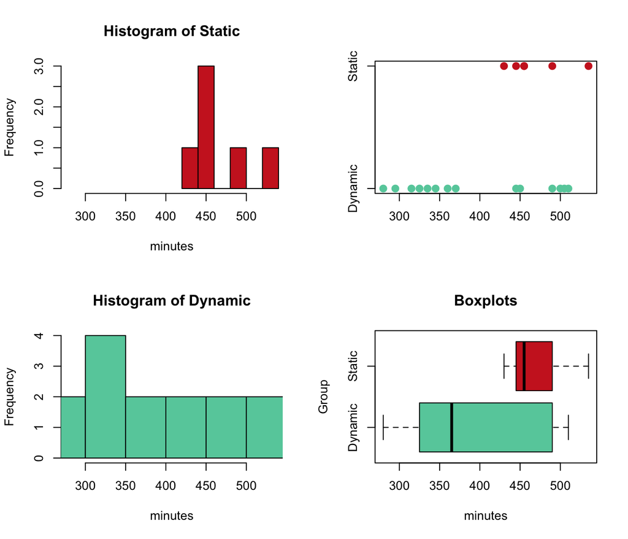

```r
par(mfrow=c(2,2))

# Histogram
hist(Static,col="firebrick3 ",xlim = c(280,535.0),xlab="minutes")

# Dotplot
x <- list("Dynamic"=Dynamic,"Static"=Static)
stripchart(x,col=c("aquamarine3","firebrick3"),pch=16,cex=1.4)
hist(Dynamic,col="aquamarine3",xlim = c(280,535.0),xlab="minutes")

# Boxplot

all <- c(Dynamic,Static)
Group <- c(rep("Dynamic", 14),rep("Static", 6))

boxplot(all ~ Group, main = "Boxplots", xlab = "minutes",col=c("aquamarine3","firebrick3"),horizontal=TRUE)
```

- We can see from the above graphs that operative times with a Static system seem generally higher. However, the spread of operative times seems different.

# 5 `Step 3`. Check assumptions

Now that we have explored the data, we check the assumptions.

- `Are the two samples simple random samples?`

Yes. We know it from the data set information. We have no paired data.

- `Do the two populations are independent?`

We have a different group of data.

- `Do the two random samples come from a population with normals distributions?`

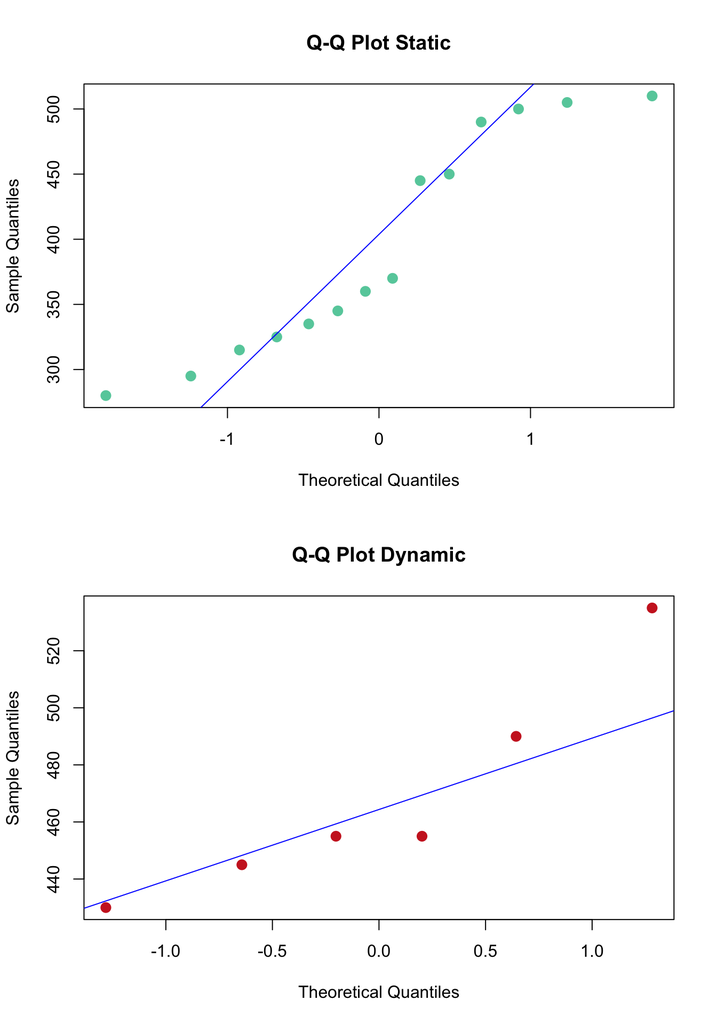

```r
par(mfrow=c(2,1))

qqnorm(Dynamic,col="aquamarine3",pch=16,cex=1.4,main = "Q-Q Plot Static")
qqline(Dynamic,col="blue")

qqnorm(Static,col="firebrick3",pch=16,cex=1.4,main = "Q-Q Plot Dynamic")
qqline(Static,col="blue")
```

The Q-Q plot is not great, but based on the neurosurgeons believe that the collection of all operative times with either device would be roughly normally distributed, we will say that the population normality assumption is reasonably met.

## 5.1 `Step 4`. Perform the appropriate test statistic

Since we have not equal variances, we will use Welch’s t-test. The `statistic` is:

$$T = \dfrac{\bar{X}_{D} - \bar{X}_{S} - 0}{\sqrt{\dfrac{S^{2}_{D}}{n_{D}} + \dfrac{S^{2}_{S}}{n_{S}}}}\;;\;\; \textrm{with}\;\; df = \dfrac{\left(\frac{S^{2}_{D}}{n_{D}} + \dfrac{S^{2}_{S}}{n_{S}}\right)^{2}}{\dfrac{(S^{2}_{D}/n_{D})^2}{n_{D}-1} + \dfrac{(S^{2}_{S}/n_{S})^2}{n_{S}-1}}$$

The observed statistics using R by hand is

```r
t.obs<-(mean(Dynamic)-mean(Static))/sqrt((var(Dynamic)/length(Dynamic))+(var(Static)/length(Static)))
t.obs
```

```
## [1] -2.68042
```

$$t_{obs} = \dfrac{394.64 - 468.33 - 0}{\sqrt{\dfrac{7182.55}{14} + \dfrac{1456.67}{6}}}=-2.68\;;\;\; \textrm{with}\;\; df = \frac{\left(\frac{7182.55}{14} + \frac{1456.67}{6}\right)^{2}}{\frac{(84.75/14)^2}{14-1} + \frac{(38.17/6)^2}{6-1}} = 17.83.$$

# 6 Methods to take a decision

## 6.1 `Method 1: Rejection region`

Since $\alpha= 0.05$ and df=17.83. We put $0.025$ in the left and right tails of the t distribution. The rejection region is defined by:

$$\bbox[#ffcc99,20px,border:10px ligth red]
{
\textrm{Reject}\;H_0:\;T>t_{17.83,0.975}\;\;\textrm{or}\;\;T<t_{17.83,0.025}
}$$

Where $t_{17.83,0.025}$ and $t_{17.83,0.975}$ are the critical values. We can compute them using R:

```r
t.1<-qt(0.025, df=df)
t.1
```

```
## [1] -2.102339
```

```r
t.2<-qt(0.975, df=df)
t.2
```

```
## [1] 2.102339
```

The critical values are $t_{(17.83,0.025)} = -2.1$ and $t_{(17.83,0.975)} = 2.1$.

Then the rejection region is

$$\bbox[#ffcc99,20px,border:10px ligth red]
{
\textrm{Reject}\; H_0\; \textrm{if:}\; T>2.1 \;\;\textrm{or}\;\; T<-2.1
}$$

- Since the t.obs=$-2.68$ do fall into the rejection region, we reject the null hypothesis.

## 6.2 `Method 2: P-value`

In R:

```r
p.value<-pt(q=t.obs,df=df)
p.value
```

```
## [1] 0.007679065
```

It was calculated as

$$\textrm{p-value}=P(T_{17.83}<-2.68)=0.0076791.$$

- Since the p-value is relatively small, $\textrm{p-value}=0.0076791<0.05$, we reject the nul hypothesis $H_0:\mu_D-\mu_S=0$.

# 7 `Method 3: Confidence interval.`

Again we can make a confidence interval. The form is again the same, but the estimated standard error of the estimate changes. The`interval estimator` is given by

$$\bar{X}_{D} - \bar{X}_{S} \pm t_{df, \alpha/2} * \sqrt{\frac{S^{2}_{D}}{n_{D}} + \frac{S^{2}_{D}}{n_{D}}}$$

- Computation in R by steps

```r
dif.mean<-mean(Dynamic)-mean(Static)
dif.mean
```

```
## [1] -73.69048
```

```r
var<-((sd(Dynamic)^2)/length(Dynamic)+(sd(Static)^2)/length(Static))
var
```

```
## [1] 755.8174
```

```r
se<-sqrt(var)
se
```

```
## [1] 27.49213
```

```r
t=qt(p=alpha2, df=df)

t
```

```
## [1] 2.102339
```

```r
E= t*se
E
```

```
## [1] 57.79779
```

```r
ci.lower=dif.mean-E
ci.lower
```

```
## [1] -131.4883
```

```r
ci.upper=dif.mean+E
ci.upper
```

```
## [1] -15.89269
```

- Thus an approximate $95\%$ confidence interval for $\mu_{\textrm{D}} -\mu_{\textrm{S}}$ would be $(-131.49,-15.89)$ or
  $$-131.49<\;\;\mu_{\textrm{D}} - \mu_{\textrm{S}}< -15.89.$$

Since the interval does not cover zero, we would reject the null hypothesis that the difference is zero, just as we concluded using the test.

## 7.1 In R using the `t.test()` function

```r
t.test(Dynamic, Static, paired=FALSE, var.equal=FALSE, conf.level=.95, alternative="less")
```

```
##
##  Welch Two Sample t-test
##
## data:  Dynamic and Static
## t = -2.6804, df = 17.832, p-value = 0.007679
## alternative hypothesis: true difference in means is less than 0
## 95 percent confidence interval:
##       -Inf -25.99307
## sample estimates:
## mean of x mean of y
##  394.6429  468.3333
```

Where

1. `alternative = "less"` since the alternative hypothesis is $(H_0:\mu_{D}-\mu_{S}< 0)$.
2. `mu = 0` since the value under the null hypothesis is 0 $(H_0:\mu_{D}-\mu_{S}=0)$.
3. `paired = FALSE` since the two populations are independent.
4. `var.equal = FALSE` since the two populations variance is different.
5. `conf.level` = 0.95 since the level of significance is $\alpha=0.05$.
- `P-value:` The p-value is $0.0076791$ which is less than $\alpha=0.05$. Thus, we have sufficient evidence to reject the null hypothesis at the $\alpha=0.05$ level.
- `Confidence interval:` The $95\%$ one-sided confidence interval for the true difference in operating time between the dynamic and static system is $(-\infty{}, -25.99)$ minutes. Since this interval does not include $0$ as a likely value for the true difference in means, we have evidence to reject the null hypothesis at the $\alpha=0.05$ level.

## 7.2 Using Bootstrap

```r
boottwo<-function(dat1, dat2, nboot) {

    bootstat<-NULL

    for(i in 1:nboot) {
        truediff<-mean(dat1) - mean(dat2)
        n1<-length(dat1)
        n2<-length(dat2)
        samp1<-sample(dat1, size = n1, replace = T)
        samp2<-sample(dat2, size = n2, replace = T)
        bootmean1<-mean(samp1)
        bootmean2<-mean(samp2)
        bootvar1<-var(samp1)
        bootvar2<-var(samp2)
        bootstat[i]<-(bootmean1 - bootmean2 - truediff)/sqrt((bootvar1/n1) + (bootvar2/n2))
}

    return(bootstat)
}
```

- Run the bootstrap function `boottwo()` for cricket data

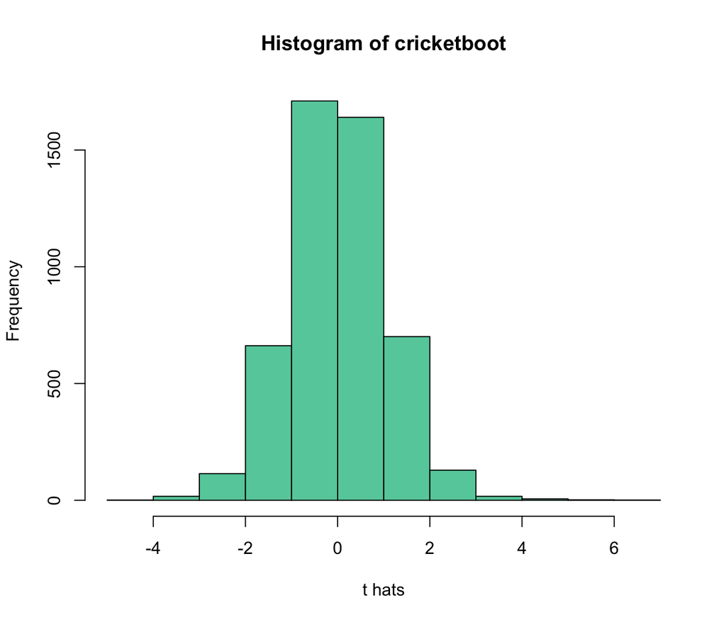

```r
set.seed(1)
cricketboot<-boottwo(Dynamic, Static, 5000) # generate 5000 simulated values of the Welch's T-test
hist(cricketboot,col="aquamarine3",xlab="t hats")
```

- Compute the observed t-test

```r
mDynamic<-mean(Dynamic)
vDynamic<-var(Dynamic)
nDynamic<-length(Dynamic)
mStatic<-mean(Static)
vStatic<-var(Static)
nStatic<-length(Static)
tobs<-(mDynamic - mStatic)/sqrt(vDynamic/nDynamic + vStatic/nStatic) # Observed t value
tobs
```

```
## [1] -2.68042
```

```r
mlo<-sum(cricketboot <= -abs(tobs))
mlo
```

```
## [1] 33
```

```r
pval<-mlo/5000
pval
```

```
## [1] 0.0066
```

We found 33 $\hat{t}$ values less than -2.68, for a p-value of $0.0066 < 0.05$. Thus, we reject the null hypothesis.

## 7.3 `Step 5`. State the conclusion and interpret the decision

There is sufficient statistical evidence to suggest that the mean operative time is lower with the dynamic system.

# 8 Problem 2

Using the information in problem 1, perform in R a Wilcoxon Rank Sum/Mann-Whitney test for evidence that the population of Dynamic surgical times is shifted left of the Static surgical times. Report the observed Test Statistic, p-value, and conclusions.

## 8.1 `Step 1.` State null and alternative hypotheses

The Hypotheses are in terms of the two population distributions `(not their means)`

$$\begin{align}
H_0:&\; \textrm{The distributions of the operation time for both groups: dynamic and static are identical}\\
H_A:&\;\textrm{The distributions of the two groups: dynamic and static have the same shape, but one is shifted relative to the other}
\end{align}$$

### 8.1.1 `Step 2.` Data exploration

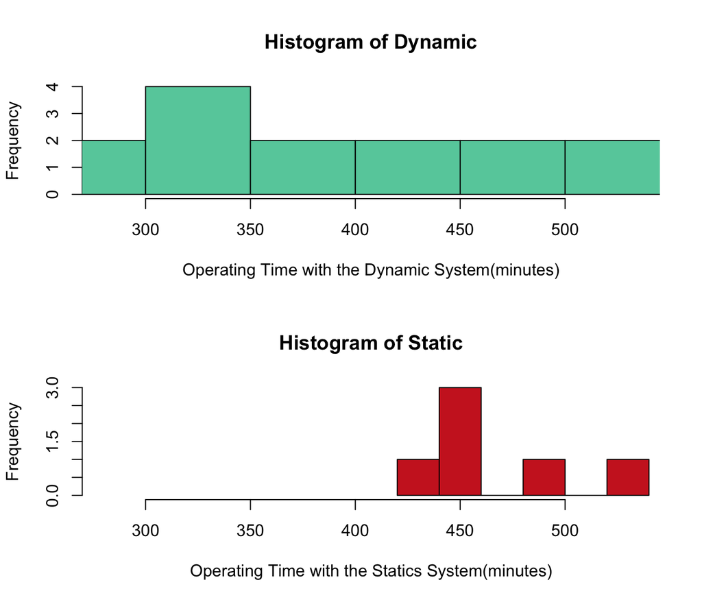

```r
par(mfrow=c(2,1))

hist(Dynamic,col="aquamarine3",xlim = c(280.0,535.0),xlab="Operating Time with the Dynamic System(minutes)")
hist(Static,col="firebrick3",xlim = c(280.0,535.0),xlab="Operating Time with the Statics System(minutes)")
```

## 8.2 `Step 3.` Check assumptions

- Note that we are talking about distributions.
1. Are there independence between and within groups?

From the data’s nature, the data are not paired, the independence between groups (Dynamic and Static) is validated.

- But if there is any concern about this assumption, we would need to use a different method. `For example, the bootstrap or permutation test, neither of which makes any assumption about the distributions` shapes.

## 8.3 `Step 4.` Perform the appropriate test statistic and take the decision

```r
wilcox.test(Dynamic, Static, alternative="less",conf.level = 0.95)
```

```
##
##  Wilcoxon rank sum test with continuity correction
##
## data:  Dynamic and Static
## W = 23, p-value = 0.06331
## alternative hypothesis: true location shift is less than 0
```